# Representation analysis of name origin in the US

Only keep articles from 2002 because few authors had nationality predictions before 2002 (mostly due to missing metadata). See 093.summary-stats for more details.

```r
load("Rdata/raws.Rdata")

alpha_threshold <- qnorm(0.975)

pubmed_nat_df <- corr_authors %>%
  filter(year(year) >= 2002) %>%
  separate_rows(countries, sep = ",") %>%
  filter(countries == "US") %>%
  left_join(nationalize_df, by = c("fore_name", "last_name")) %>%
  group_by(pmid, journal, publication_date, year, adjusted_citations) %>%
  summarise_at(vars(African:SouthAsian), mean, na.rm = T) %>%
  ungroup()

iscb_nat_df <- keynotes %>%
  separate_rows(afflcountries, sep = "\\|") %>%
  filter(afflcountries == "United States") %>%
  left_join(nationalize_df, by = c("fore_name", "last_name"))

start_year <- 1992
end_year <- 2019
n_years <- end_year - start_year
my_jours <- unique(pubmed_nat_df$journal)
my_confs <- unique(iscb_nat_df$conference)
n_jours <- length(my_jours)
n_confs <- length(my_confs)
region_levels <- paste(c("Celtic/English", "European", "East Asian", "Hispanic", "South Asian", "Arabic", "Hebrew", "African", "Nordic", "Greek"), "names")

region_cols <- c("#ffffb3", "#fccde5", "#b3de69", "#fdb462", "#80b1d3", "#8dd3c7", "#bebada", "#fb8072", "#bc80bd", "#ccebc5")
```

## Organize data

Prepare data frames for later analyses:

- rbind results of race predictions in iscb and Pubmed
- pivot long
- compute mean, sd, marginal error

```r
iscb_pubmed_oth <- iscb_nat_df %>%
  rename("journal" = conference) %>%
  select(year, journal, African:SouthAsian, publication_date) %>%
  mutate(
    type = "Keynote speakers/Fellows",
    adjusted_citations = 1
  ) %>%
  bind_rows(
    pubmed_nat_df %>%
      select(year, journal, African:SouthAsian, publication_date, adjusted_citations) %>%
      mutate(type = "Pubmed authors")
  ) %>%
  mutate(OtherCategories = SouthAsian + Hispanic + Jewish + Muslim + Nordic + Greek + African) %>%
  pivot_longer(c(African:SouthAsian, OtherCategories),
    names_to = "region",
    values_to = "probabilities"
  ) %>%
  filter(!is.na(probabilities)) %>%
  group_by(type, year, region)

iscb_pubmed_sum_oth <- iscb_pubmed_oth %>%
  summarise(
    mean_prob = mean(probabilities),
    se_prob = sd(probabilities)/sqrt(n()),
    me_prob = alpha_threshold * se_prob,
    .groups = "drop"
  )

iscb_pubmed_sum <- iscb_pubmed_sum_oth %>%
  filter(region != "OtherCategories")
```

## Figures for paper

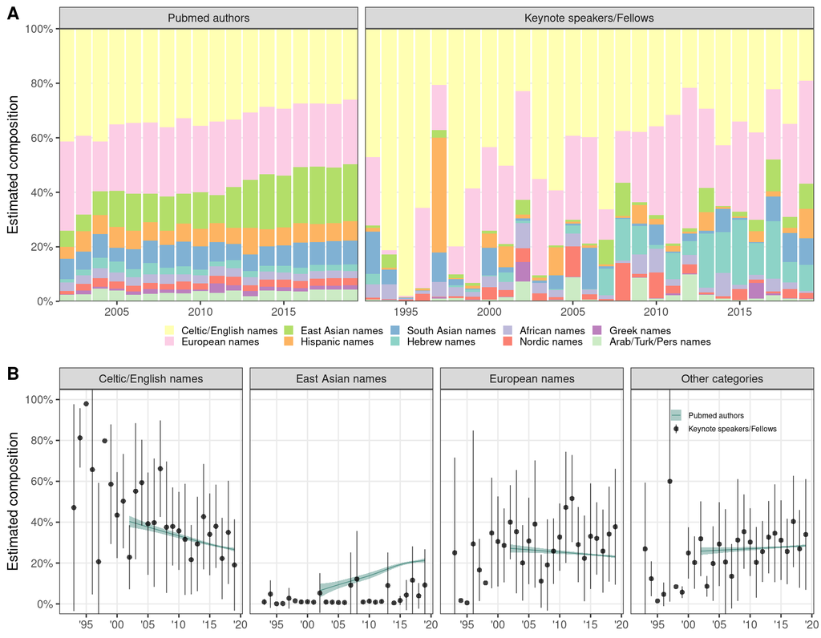

```r
fig_us_name_origina <- iscb_pubmed_sum %>%
  filter(year < "2020-01-01") %>%
  region_breakdown("main", region_levels, fct_rev(type)) +
  guides(fill = guide_legend(nrow = 2))

large_regions <- c("CelticEnglish", "EastAsian", "European", "OtherCategories")

## Mean and standard deviation of predicted probabilities:
fig_us_name_originb <- iscb_pubmed_sum_oth %>%
  filter(region %in% large_regions) %>%
  recode_region() %>%
  gam_and_ci(
    df2 = iscb_pubmed_oth %>%
      filter(region %in% large_regions) %>%
      recode_region(),
    start_y = start_year, end_y = end_year
  ) +
  theme(
    legend.position = c(0.88, 0.83),
    panel.grid.minor = element_blank(),
    legend.margin = margin(-0.5, 0, 0, 0, unit = "cm"),
    legend.text = element_text(size = 6)
  ) +
  facet_wrap(vars(fct_relevel(region, large_regions)), nrow = 1)

fig_us_name_origin <- cowplot::plot_grid(fig_us_name_origina, fig_us_name_originb, labels = "AUTO", ncol = 1, rel_heights = c(1.3, 1))
fig_us_name_origin
```

```r
ggsave("figs/us_name_origin.png", fig_us_name_origin, width = 6.5, height = 5.5, dpi = 600)
ggsave("figs/us_name_origin.svg", fig_us_name_origin, width = 6.5, height = 5.5)
```

## Hypothesis testing

```r
iscb_lm <- iscb_pubmed_oth %>%
  ungroup() %>%
  mutate(
    # year = c(scale(year)),
    # year = as.factor(year),
    type = relevel(as.factor(type), ref = "Pubmed authors")
  )
main_lm <- function(regioni) {
  glm(type ~ year + probabilities,
    data = iscb_lm %>%
      filter(region == regioni, !is.na(probabilities), year(year) >= 2002),
    family = "binomial"
  )
}

inte_lm <- function(regioni) {
  glm(type ~ probabilities * year,
    data = iscb_lm %>%
      filter(region == regioni, !is.na(probabilities), year(year) >= 2002),
    family = "binomial"
  )
}

main_list <- lapply(large_regions, main_lm)

names(main_list) <- large_regions
lapply(main_list, broom::tidy)
```

```
## $CelticEnglish
## # A tibble: 3 x 5
##   term           estimate std.error statistic  p.value
##   <chr>             <dbl>     <dbl>     <dbl>    <dbl>
## 1 (Intercept)    4.76     0.535          8.89 5.86e-19
## 2 year          -0.000611 0.0000348    -17.6  3.87e-69
## 3 probabilities  0.269    0.185          1.46 1.46e- 1
##
## $EastAsian
## # A tibble: 3 x 5
##   term           estimate std.error statistic  p.value
##   <chr>             <dbl>     <dbl>     <dbl>    <dbl>
## 1 (Intercept)    4.73     0.519          9.12 7.71e-20
## 2 year          -0.000592 0.0000346    -17.1  9.97e-66
## 3 probabilities -1.89     0.455         -4.14 3.43e- 5
##
## $European
## # A tibble: 3 x 5
##   term           estimate std.error statistic  p.value
##   <chr>             <dbl>     <dbl>     <dbl>    <dbl>
## 1 (Intercept)    4.78     0.524          9.12 7.75e-20
## 2 year          -0.000614 0.0000345    -17.8  6.78e-71
## 3 probabilities  0.446    0.194          2.30 2.16e- 2
##
## $OtherCategories
## # A tibble: 3 x 5
##   term           estimate std.error statistic  p.value
##   <chr>             <dbl>     <dbl>     <dbl>    <dbl>
## 1 (Intercept)    4.93     0.520         9.48  2.58e-21
## 2 year          -0.000618 0.0000345   -17.9   1.18e-71
## 3 probabilities  0.0957   0.212         0.451 6.52e- 1
```

```r
inte_list <- lapply(large_regions, inte_lm)
lapply(inte_list, broom::tidy)
```

```
## [[1]]
## # A tibble: 4 x 5
##   term                  estimate std.error statistic  p.value
##   <chr>                    <dbl>     <dbl>     <dbl>    <dbl>
## 1 (Intercept)         4.81       0.730        6.60   4.16e-11
## 2 probabilities       0.128      1.32         0.0969 9.23e- 1
## 3 year               -0.000615   0.0000479  -12.8    9.81e-38
## 4 probabilities:year  0.00000953 0.0000883    0.108  9.14e- 1
##
## [[2]]
## # A tibble: 4 x 5
##   term                 estimate std.error statistic  p.value
##   <chr>                   <dbl>     <dbl>     <dbl>    <dbl>
## 1 (Intercept)         4.71      0.536         8.78  1.57e-18
## 2 probabilities      -1.29      3.81         -0.339 7.34e- 1
## 3 year               -0.000591  0.0000357   -16.5   1.68e-61
## 4 probabilities:year -0.0000380 0.000243     -0.157 8.76e- 1
##
## [[3]]
## # A tibble: 4 x 5
##   term                 estimate std.error statistic  p.value
##   <chr>                   <dbl>     <dbl>     <dbl>    <dbl>
## 1 (Intercept)         5.17      0.674         7.67  1.77e-14
## 2 probabilities      -0.809     1.40         -0.577 5.64e- 1
## 3 year               -0.000640  0.0000449   -14.3   3.42e-46
## 4 probabilities:year  0.0000840 0.0000926     0.906 3.65e- 1
##
## [[4]]
## # A tibble: 4 x 5
##   term                 estimate std.error statistic  p.value
##   <chr>                   <dbl>     <dbl>     <dbl>    <dbl>
## 1 (Intercept)         5.22      0.670         7.79  6.76e-15
## 2 probabilities      -0.964     1.59         -0.605 5.45e- 1
## 3 year               -0.000637  0.0000447   -14.2   4.57e-46
## 4 probabilities:year  0.0000701 0.000104      0.673 5.01e- 1
```

```r
for (i in 1:4) {
  print(anova(main_list[[i]], inte_list[[i]], test = "Chisq"))
}
```

```
## Analysis of Deviance Table
##
## Model 1: type ~ year + probabilities
## Model 2: type ~ probabilities * year
##   Resid. Df Resid. Dev Df Deviance Pr(>Chi)
## 1     26398     2064.9
## 2     26397     2064.9  1 0.011635   0.9141
## Analysis of Deviance Table
##
## Model 1: type ~ year + probabilities
## Model 2: type ~ probabilities * year
##   Resid. Df Resid. Dev Df Deviance Pr(>Chi)
## 1     26398     2036.7
## 2     26397     2036.7  1 0.024177   0.8764
## Analysis of Deviance Table
##
## Model 1: type ~ year + probabilities
## Model 2: type ~ probabilities * year
##   Resid. Df Resid. Dev Df Deviance Pr(>Chi)
## 1     26398     2061.9
## 2     26397     2061.1  1  0.82361   0.3641
## Analysis of Deviance Table
##
## Model 1: type ~ year + probabilities
## Model 2: type ~ probabilities * year
##   Resid. Df Resid. Dev Df Deviance Pr(>Chi)
## 1     26398     2066.8
## 2     26397     2066.3  1  0.45537   0.4998
```

Interaction terms do not predict `type` over and above the main effect of name origin probability and year (*p* > 0.01).

## Supplement

### Supplementary Figure S7

It’s difficult to come to a conclusion for other regions with so few data points and the imperfect accuracy of our prediction. There seems to be little difference between the proportion of keynote speakers of African, Arabic, South Asian and Hispanic origin than those in the field. However, just because a nationality isn’t underrepresented against the field doesn’t mean scientists from that nationality are appropriately represented.

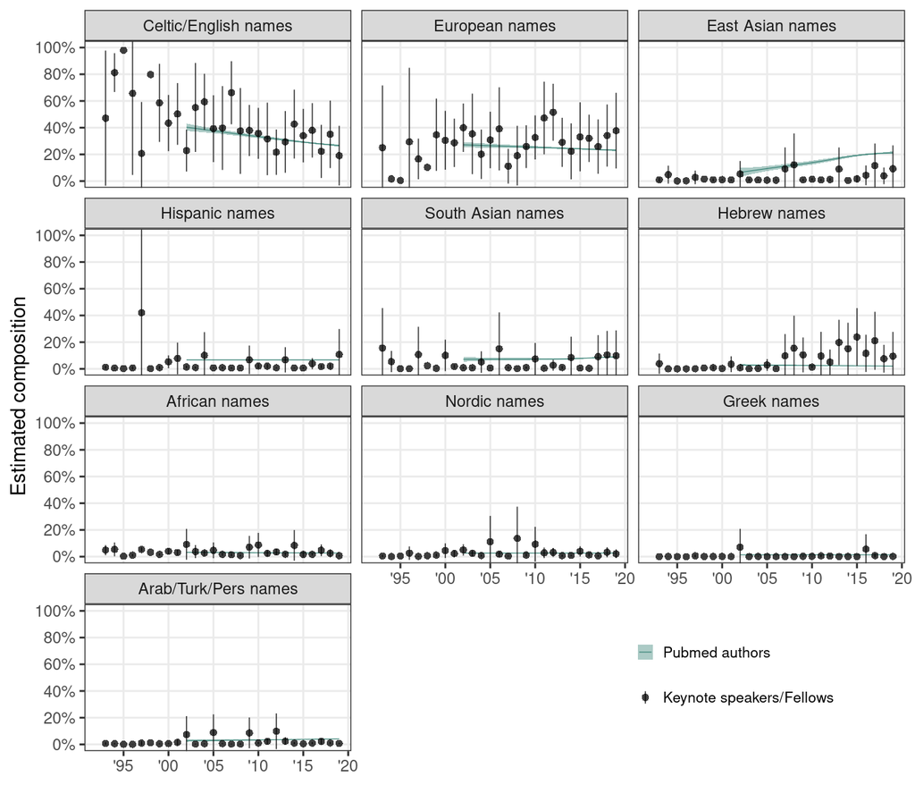

```r
df2 <- iscb_pubmed_oth %>%
  filter(region != "OtherCategories") %>%
  recode_region()

fig_s7 <- iscb_pubmed_sum %>%
  recode_region() %>%
  gam_and_ci(
    df2 = df2,
    start_y = start_year, end_y = end_year
  ) +
  theme(legend.position = c(0.8, 0.1)) +
  facet_wrap(vars(fct_relevel(region, region_levels)), ncol = 3)

fig_s7
```

```r
ggsave("figs/fig_s7.png", fig_s7, width = 6, height = 6)
ggsave("figs/fig_s7.svg", fig_s7, width = 6, height = 6)
```